# Replication of Figure I–J: YAP1, TAZ, and TEAD4 Co-occupancy at Promoters and Enhancers

Harshini Muthukumar

2026-03-19

### Figure 1I

From the figure description:

**Heatmap representing YAP/TAZ/TEAD binding sites located on promoters (top) and enhancers (bottom)**. YAP, TAZ and TEAD4 peaks are ranked from the strongest to weakest signal in TAZ ChIP, in a window of ±1kb centered on the summit of TAZ peaks. H3K4me1 and H3K4me3 signal in the corresponding genomic regions is shown on the right.

From the method section:

Heatmaps were generated using a custom R script which considers a **2-kb window centered on peak summits and calculates the normalized reads density with a resolution of 50 bp**.

The rows are different peaks. The columns are 2kb window centered on the summit of the TAZ peaks with 50 bp per bin. So it will be 2000/50 = 40 bins for the columns.The signal is the normalized read counts in each bin.

```r
suppressWarnings(
  suppressMessages({
    library(rtracklayer)
    library(here)
    library(dplyr)
    library(ggplot2)
    library(EnrichedHeatmap)
  })
)

TAZ_peaks<- import(here("C:/Users/harzi/OneDrive/Desktop/chip_seq_peak/TAZ_peaks.narrowPeak"))
YAP_peaks<- import(here("C:/Users/harzi/OneDrive/Desktop/chip_seq_peak/YAP_peaks.narrowPeak"))
TEAD4_peak<- import(here("C:/Users/harzi/OneDrive/Desktop/chip_seq_peak/TEAD4_peaks.narrowPeak"))

YAP_overlap_TAZ_peaks<-suppressWarnings(subsetByOverlaps(YAP_peaks, TAZ_peaks))

YAP_overlap_TAZ_peaks_overlap_TEAD4<- suppressWarnings(subsetByOverlaps(YAP_overlap_TAZ_peaks, TEAD4_peak))
```

Since I focused on YAP1, I will use the summit of YAP1 as the anchor point (can of course change it to TAZ too)

```r
YAP_summit<- import(here("C:/Users/harzi/OneDrive/Desktop/chip_seq_peak/YAP_summits.bed"))
```

[output not shown]

```r
dim(mat1)
```

```
## [1] 3762   40
```

```r
dim(mat2)
```

```
## [1] 3762   40
```

```r
dim(mat3)
```

```
## [1] 3762   40
```

```r
mat1[1:5, 1:40 ]
```

```
##            u1       u2        u3       u4      u5        u6       u7       u8
## [1,] 2.536570 2.536570 2.5365701 1.707960 1.69105 2.5196597 2.536570 3.365190
## [2,] 0.845524 0.845524 0.3720306 0.000000 0.00000 0.4734934 1.792510 2.536570
## [3,] 3.077709 3.382100 3.9232329 5.851025 6.76419 5.1407854 4.227620 3.686487
## [4,] 2.874780 4.565830 5.5804602 4.227620 4.22762 4.0585161 3.043890 1.521945
## [5,] 4.227620 4.227620 4.5658321 4.396730 3.38210 3.0438881 2.874782 3.043888
##            u9      u10       u11       u12      u13      u14      u15      u16
## [1,] 3.382100 5.039329 4.2445307 3.3990105 5.039329 4.244531 3.399011 4.210710
## [2,] 3.010067 4.329088 4.5996533 3.7541289 3.382100 3.382100 2.908603 3.483558
## [3,] 1.758691 0.845524 0.3043886 0.5411354 0.845524 1.927793 3.077709 4.464372
## [4,] 1.183733 2.536570 2.7056761 3.7203101 5.073150 4.904044 4.396726 5.242254
## [5,] 2.874782 3.043888 3.2129901 3.8894121 4.058520 4.396730 3.720308 4.565832
##           u17       u18      u19      u20       d1       d2        d3       d4
## [1,] 6.713459  7.592810  7.60972 10.92416 11.82039 10.18012  7.660452 9.266949
## [2,] 5.648099  9.131652 11.46528 12.31084 11.73588 10.51832  7.778827 5.445179
```

[output cut: 21 more lines]

```r
quantile(mat1, c(0.1,0.25,0.5,0.9,1))
```

```
##        10%        25%        50%        90%       100%
##   1.149913   2.536570   4.278352  17.553077 330.667809
```

```r
quantile(mat2, c(0.1,0.25,0.5,0.9,1))
```

```
##        10%        25%        50%        90%       100%
##   1.418455   2.388982   4.479340  17.887536 417.026313
```

```r
quantile(mat3, c(0.1,0.25,0.5,0.9,1))
```

```
##        10%        25%        50%        90%       100%
##   1.234964   2.330130   4.031118  19.363364 390.272531
```

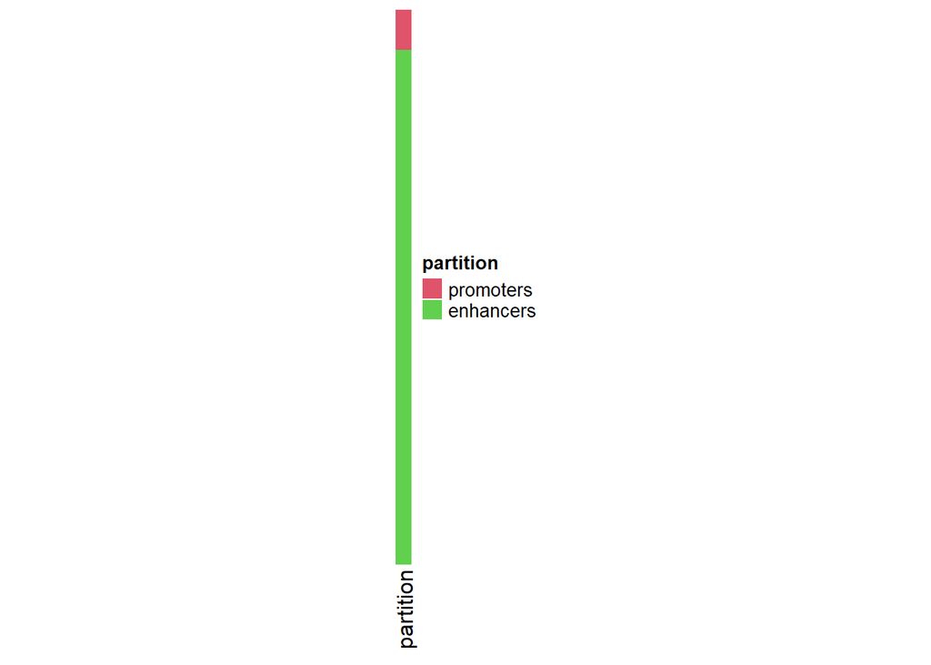

```r
partition<- c(rep("promoters", length(YAP1_promoters)),
              rep("enhancers", length(YAP1_enhancers)))

# change the factor level so promoters come first
partition<- factor(partition, levels=c("promoters", "enhancers"))

partition_hp<- Heatmap(partition, col=structure(2:3, names = c("promoters", "enhancers")),
        name = "partition",
        show_row_names = FALSE, width=unit(3,'mm'))

partition_hp
```

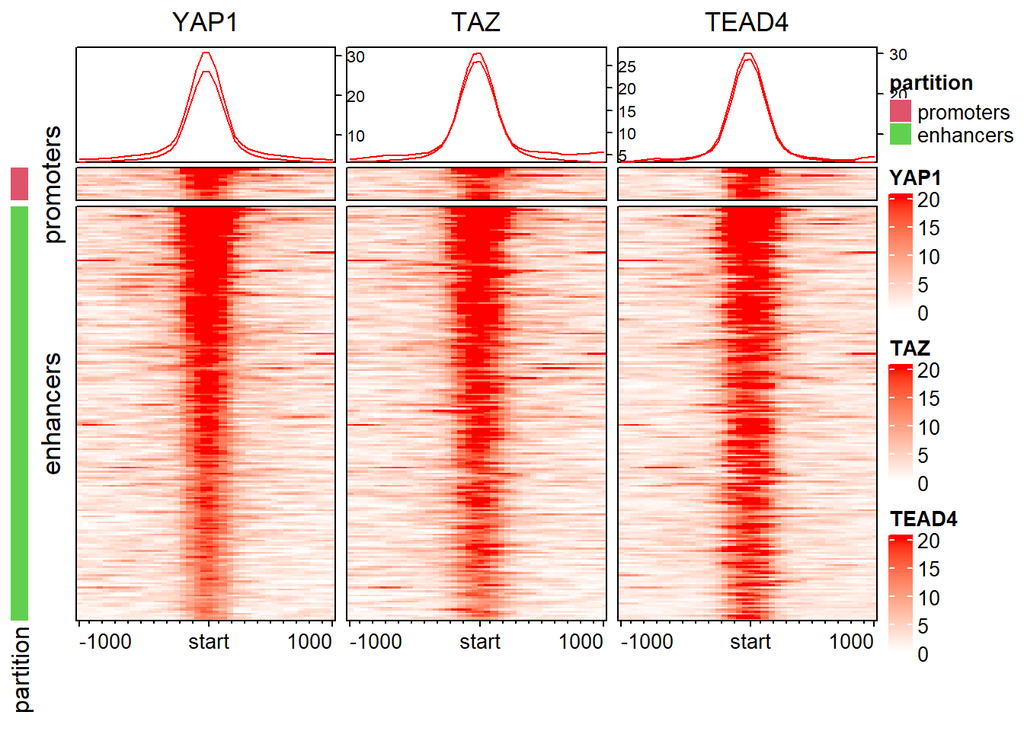

```r
ht_opt$message = FALSE

ht_list<- partition_hp +
  EnrichedHeatmap(mat1, pos_line = FALSE, column_title="YAP1", name = "YAP1", col=col_fun) +
  EnrichedHeatmap(mat2, pos_line = FALSE, column_title="TAZ", name = "TAZ", col=col_fun) +
  EnrichedHeatmap(mat3, pos_line = FALSE, column_title="TEAD4", name = "TEAD4", col=col_fun)

draw(ht_list, split= partition, main_heatmap =2)
```

## FIG 1 J

Figure description:

Bimodal distribution of H3K4me1 signal around the summit of YAP/TAZ and TEAD4 peaks.

The line plot is just the average of all the peaks per column.

```r
YAP1_mean<- colMeans(mat1)
TAZ_mean<- colMeans(mat2)
TEAD4_mean<- colMeans(mat3)
```

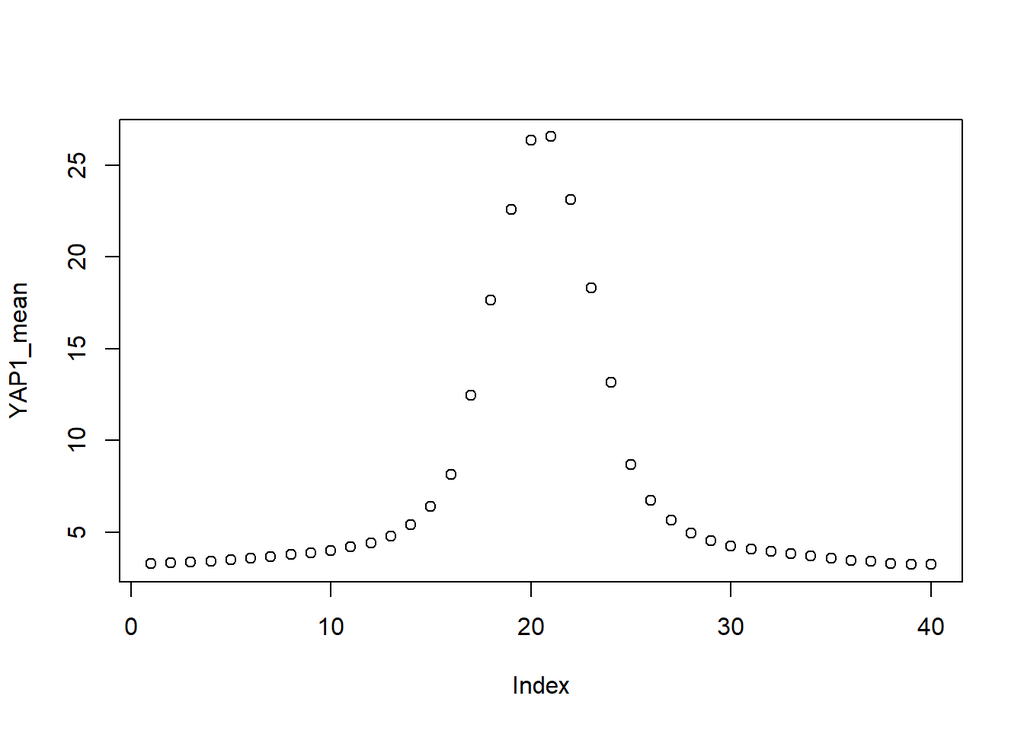

```r
plot(YAP1_mean)
```

```r
bind_rows(YAP1_mean, TAZ_mean, TEAD4_mean) %>%
  mutate(factor = c("YAP1", "TAZ", "TEAD4")) %>%
  select(factor, everything())
```

```
## # A tibble: 3 × 41
##   factor    u1    u2    u3    u4    u5    u6    u7    u8    u9   u10   u11   u12
##   <chr>  <dbl> <dbl> <dbl> <dbl> <dbl> <dbl> <dbl> <dbl> <dbl> <dbl> <dbl> <dbl>
## 1 YAP1    3.29  3.34  3.37  3.43  3.49  3.58  3.67  3.78  3.88  4.01  4.19  4.40
## 2 TAZ     3.35  3.41  3.46  3.51  3.57  3.66  3.76  3.85  3.93  4.08  4.29  4.55
## 3 TEAD4   3.08  3.13  3.17  3.24  3.30  3.38  3.45  3.52  3.60  3.71  3.89  4.17
## # ℹ 28 more variables: u13 <dbl>, u14 <dbl>, u15 <dbl>, u16 <dbl>, u17 <dbl>,
## #   u18 <dbl>, u19 <dbl>, u20 <dbl>, d1 <dbl>, d2 <dbl>, d3 <dbl>, d4 <dbl>,
## #   d5 <dbl>, d6 <dbl>, d7 <dbl>, d8 <dbl>, d9 <dbl>, d10 <dbl>, d11 <dbl>,
## #   d12 <dbl>, d13 <dbl>, d14 <dbl>, d15 <dbl>, d16 <dbl>, d17 <dbl>,
## #   d18 <dbl>, d19 <dbl>, d20 <dbl>
```

```r
bind_rows(YAP1_mean, TAZ_mean, TEAD4_mean) %>%
  mutate(factor = c("YAP1", "TAZ", "TEAD4")) %>%
  select(factor, everything()) %>%
  tidyr::pivot_longer(-factor)
```

```
## # A tibble: 120 × 3
##    factor name  value
##    <chr>  <chr> <dbl>
##  1 YAP1   u1     3.29
##  2 YAP1   u2     3.34
##  3 YAP1   u3     3.37
##  4 YAP1   u4     3.43
##  5 YAP1   u5     3.49
##  6 YAP1   u6     3.58
##  7 YAP1   u7     3.67
##  8 YAP1   u8     3.78
##  9 YAP1   u9     3.88
## 10 YAP1   u10    4.01
## # ℹ 110 more rows
```

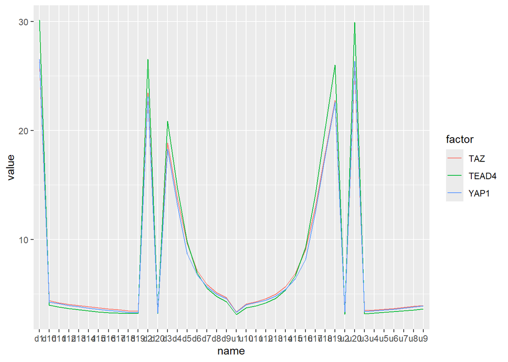

```r
bind_rows(YAP1_mean, TAZ_mean, TEAD4_mean) %>%
  mutate(factor = c("YAP1", "TAZ", "TEAD4")) %>%
  select(factor, everything()) %>%
  tidyr::pivot_longer(-factor) %>%
  ggplot(aes(x=name, y=value)) +
  geom_line(aes(color = factor, group=factor))
```

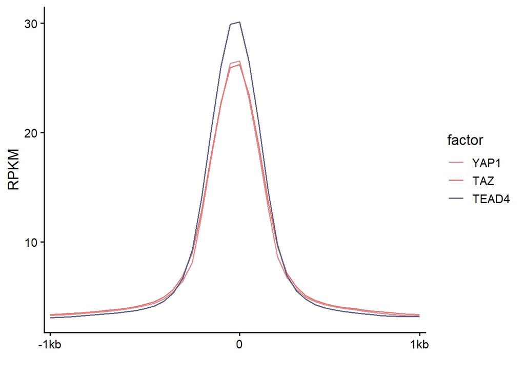

```r
bind_rows(YAP1_mean, TAZ_mean, TEAD4_mean) %>%
  mutate(factor = factor(c("YAP1", "TAZ", "TEAD4"), levels = c("YAP1", "TAZ", "TEAD4"))) %>%
  select(factor, everything()) %>%
  tidyr::pivot_longer(-factor) %>%
  mutate(name = factor(name, levels = c(paste0("u",1:20), paste0("d", 1:20)))) %>%
  ggplot(aes(x=name, y=value)) +
  geom_line(aes(color = factor, group=factor)) +
  scale_x_discrete(breaks=c("u1", "d1", "d20"), labels = c("-1kb", "0", "1kb")) +
  scale_color_manual(values = c("#DA9195", "#E07B78", "#605D7D")) +
  theme_classic(base_size = 14) +
  ylab("RPKM") +
  xlab("")
```